# Chick Weight Report - Target

Saghir Bashir

Tue 29 Oct 2019 (11:31:33)

# Chick Weight Data

> *“The body weights of the chicks were measured at birth and every second day thereafter until day 20. They were also measured on day 21. There were four groups of chicks on different protein diets.”*

## The Data

There are 578 observations (rows) and 4 variables:

- `Chick` – unique ID for each chick.
- `Diet` – one of four protein diets.
- `Time` – number of days since birth.
- `weight` – body weight of chick in grams.

## Objective

Investigate the *effect of diet on the weight over time*.

# Importing the Data

```r
library(data.table)
cw <- fread("ChickWeight.csv")
cw
```

```
##      Chick Diet Time weight
##   1:    18    1    0     39
##   2:    18    1    2     35
##   3:    16    1    0     41
##   4:    16    1    2     45
##   5:    16    1    4     49
##  ---
## 574:    48    4   14    170
## 575:    48    4   16    222
## 576:    48    4   18    261
## 577:    48    4   20    303
## 578:    48    4   21    322
```

## Preparing the Data

Before we continue, we have to make an important change to the `cw` dataset by making `Diet` and `Time` *factor variables*. This means that R will treat them as categorical variables instead of continuous variables. It will simplify our coding.

```r
setnames(cw, c("weight"), c("Weight"))
cw[, Group := factor(paste0("Diet ", Diet))][
   , Time := factor(Time)][
   , Diet:=NULL]
setcolorder(cw, c("Group", "Chick", "Time", "Weight"))
str(cw)
```

```
## Classes 'data.table' and 'data.frame':   578 obs. of  4 variables:
##  $ Group : Factor w/ 4 levels "Diet 1","Diet 2",..: 1 1 1 1 1 1 1 1 1 1 ...
##  $ Chick : int  18 18 16 16 16 16 16 16 16 15 ...
##  $ Time  : Factor w/ 12 levels "0","2","4","6",..: 1 2 1 2 3 4 5 6 7 1 ...
##  $ Weight: int  39 35 41 45 49 51 57 51 54 41 ...
##  - attr(*, ".internal.selfref")=<externalptr>
```

```r
cw
```

```
##       Group Chick Time Weight
##   1: Diet 1    18    0     39
##   2: Diet 1    18    2     35
##   3: Diet 1    16    0     41
##   4: Diet 1    16    2     45
##   5: Diet 1    16    4     49
##  ---
## 574: Diet 4    48   14    170
## 575: Diet 4    48   16    222
## 576: Diet 4    48   18    261
## 577: Diet 4    48   20    303
## 578: Diet 4    48   21    322
```

## Data Checks

Both of these show that the dataset has 578 observations and 4 variables as we would expect and as compared to the original data file `ChicWeight.csv`.

# Chick Weight: Data Visualisation

## Box-whisker plot

To see variation between the different diets we will look at a box-whisker plot over time by diet. The number of chicks per diet is relatively low to produce this plot so interpret with caution.

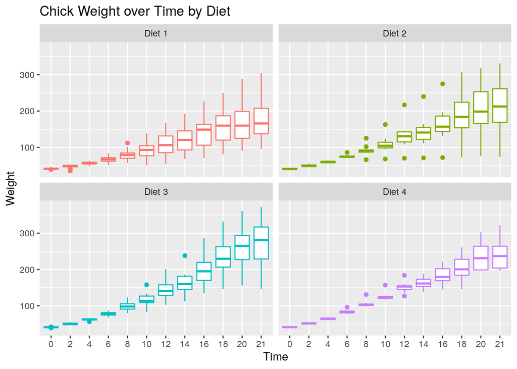

```r
library(ggplot2)
ggplot(cw, aes(Time, Weight, colour=Group)) +
  facet_wrap(~Group) +
  geom_boxplot() +
  theme(legend.position = "none") +
  ggtitle("Chick Weight over Time by Diet")
```

## Scatter Plot with Mean Lines

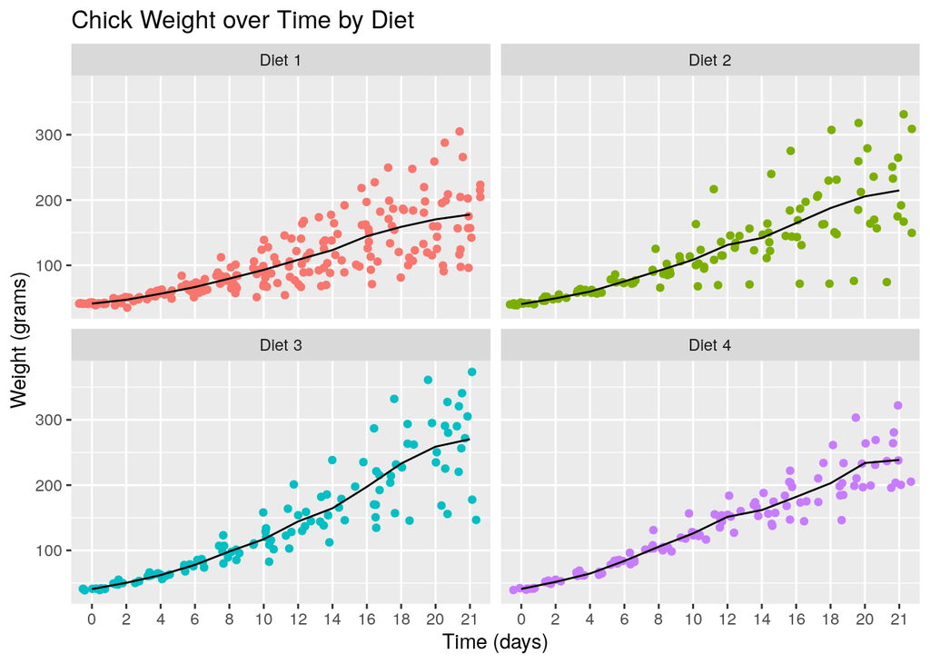

```r
ggplot(cw, aes(Time, Weight, group=Group, colour=Group)) +
  facet_wrap(~Group) +
  geom_jitter() +
  stat_summary(fun.y="mean", geom="line", colour="black") +
  theme(legend.position = "none") +
  ggtitle("Chick Weight over Time by Diet") +
  xlab("Time (days)") +
  ylab("Weight (grams)")
```

## Interpretation

Diet 3 seems to have the highest “average” weight gain but it has more variation than diet 4.

# Chick Weight: Summary Statistics

In this section, we will quantify the effects of the diets using summary statistics. We start by looking at the number of observations and the mean of weight grouped by **diet** and **time**.

```r
cws <- cw[ ,
          .(N      = .N,
            Mean   = mean(Weight),
            SDev   = sd(Weight),
            Median = median(Weight),
            Min    = min(Weight),
            Max    = max(Weight)  ),
          by=.(Group, Time)]
# Pretty Table for days 0 and 21
library(magrittr)
library(knitr)
library(kableExtra)
cws[Time %in% c(0, 21)] %>%
  kable(align="ccrrrrrr", digits = c(0, 0, 0, 1, 1, 2, 0, 0)) %>%
  kable_styling(bootstrap_options = "striped", font_size = 24, full_width = TRUE) %>%
  column_spec(1:8, width = "4em") %>%
  collapse_rows(1, valign = "top")
```

| Group | Time | N | Mean | SDev | Median | Min | Max |
| --- | --- | --- | --- | --- | --- | --- | --- |
| Diet 1 | 0 | 20 | 41.4 | 1.0 | 41.0 | 39 | 43 |
|  | 21 | 16 | 177.8 | 58.7 | 166.0 | 96 | 305 |
| Diet 2 | 0 | 10 | 40.7 | 1.5 | 40.5 | 39 | 43 |
|  | 21 | 10 | 214.7 | 78.1 | 212.5 | 74 | 331 |
| Diet 3 | 0 | 10 | 40.8 | 1.0 | 41.0 | 39 | 42 |
|  | 21 | 10 | 270.3 | 71.6 | 281.0 | 147 | 373 |
| Diet 4 | 0 | 10 | 41.0 | 1.1 | 41.0 | 39 | 42 |
|  | 21 | 9 | 238.6 | 43.3 | 237.0 | 196 | 322 |

## Interpretation

This summary table offers the same interpretation as before, namely that diet 3 has the highest mean and median weights at day 21 but a higher variation than group 4. However it should be noted that at day 21, diet 1 lost 4 chicks from 20 that started and diet 4 lost 1 from 10. This could be a sign of some issues (e.g. safety).

## Limitations of data

Information on bias reduction measures is not given and is not available either. We don’t know if the chicks were fairly and appropriately randomised to the diets and whether the groups are comparable (e.g., same breed of chicks, sex (gender) balance). Hence we should be very cautious with drawing conclusion and taking actions with this data.